# 第15回 回帰分析，他のトピック

プログラミング演習Ⅱ

佐藤 秀保

sato0035@toyo.jp

## 前回までの内容

- maplotlibによる散布図，ヒストグラム，箱ひげ図の作成

```python
#以下は実行不要
#データはアップロード済みと仮定
import pandas as pd
df = pd.read_csv("s2025_aki_clean.csv")

#散布図
plt.scatter(df["sales"], df["n_customers"])
plt.xlabel("sales")
plt.ylabel("n_customers")
plt.title("Sales vs Number of Customers")
plt.tight_layout()
plt.show()

#散布図（色など変更）
import matplotlib.pyplot as plt
plt.scatter(
    df["sales"],
    df["n_customers"],
    color="tab:green",  # 色
    marker="^",         # 形
    s=40,               # 大きさ
    alpha=0.6           # 透明度
)
plt.xlabel("sales")
plt.ylabel("n_customers")
plt.title("Sales vs Number of Customers")
plt.tight_layout()
plt.show()

#散布図（近似直線）
x = df["sales"]
y = df["n_customers"]
plt.scatter(df["sales"], df["n_customers"])
coef = np.polyfit(x, y, 1)
y_hat = np.poly1d(coef)(x)
plt.plot(x, y_hat,
         color="red",      #色
         linestyle="-",   #スタイル
         linewidth=5)      #太さ
plt.show()

#ヒストグラム
plt.hist(df["sales"])
plt.xlabel("sales")
plt.ylabel("frequency")
plt.title("Histogram of Sales")
plt.tight_layout()
plt.show()

#ヒストグラム（色など変更）
plt.hist(
    df["sales"],
    bins=30,              # ビン（棒）の数
    edgecolor="black",    # 枠線
    color="green",        # 塗りつぶし色
    hatch="//",           # パターン
    alpha=0.7             # 透明度
)
plt.xlabel("sales")
plt.ylabel("frequency")
plt.title("Histogram of Sales")
plt.tight_layout()
plt.show()

#ヒストグラム（複数）
df["date"] = pd.to_datetime(df["date"])
sales_10 = df[df["date"].dt.month == 10]["sales"]
sales_11 = df[df["date"].dt.month == 11]["sales"]
plt.hist(
    sales_10,
    bins=15,              # ビン（棒）の数
    edgecolor="black",    # 枠線
    color="tab:blue",     # 塗りつぶし色
    alpha=0.7,            # 透明度
    label="October"       # 凡例
)
plt.hist(
    sales_11,
    bins=15,              # ビン（棒）の数
    edgecolor="black",    # 枠線
    color="tab:green",    # 塗りつぶし色
    alpha=0.7,            # 透明度
    hatch="//",           # パターン
    label="November"      # 凡例
)
plt.xlabel("sales")
plt.ylabel("frequency")
plt.title("Sales Distribution: October vs November")
plt.legend()
plt.tight_layout()
plt.show()

#箱ひげ図
plt.boxplot(df["sales"])
plt.ylabel("sales")
plt.title("Boxplot of Sales")
plt.tight_layout()
plt.show()

#箱ひげ図（色など変更）
plt.boxplot(
    df["sales"],
    patch_artist=True,    #塗りつぶし有効化
    boxprops={"facecolor":"tab:blue", "alpha":0.6},
    medianprops={"color":"black", "linewidth":2},
    whiskerprops={"color":"black"},
    capprops={"color":"black"},
    flierprops={"marker":"o", "markerfacecolor":"gray", "alpha":0.5}
)
plt.ylabel("sales")
plt.title("Boxplot of Sales")
plt.tight_layout()
plt.show()

#箱ひげ図（jitter）
y = df["sales"]
plt.boxplot(y)
x = np.random.normal(1, 0.05, size=len(y))
plt.plot(x, y, "o", alpha=0.4)
plt.ylabel("sales")
plt.title("Boxplot of Sales (with jittered points)")
plt.tight_layout()
plt.show()

#箱ひげ図（複数）
df["date"] = pd.to_datetime(df["date"])
sales_10 = df[df["date"].dt.month == 10]["sales"]
sales_11 = df[df["date"].dt.month == 11]["sales"]
plt.boxplot(
    [sales_10, sales_11],
    labels=["October", "November"]
)
plt.ylabel("sales")
plt.title("Sales Distribution: October vs November")
plt.tight_layout()
plt.show()
```

## 準備

1. [Colab](https://colab.research.google.com/?hl=ja).にアクセス
2. 左下「ノートブックを新規作成」
3. 左上のノートブック名を「lec15」などに変更
4. 右側に「リリースノート」が出る場合は×で消す
5. 朝霞キャンパス食堂のデータ「df.csv」読込
   - 2025年4月1日～2026年1月14日の日別データ（営業日のみ）

```python
from google.colab import files
uploaded = files.upload()
```

```python
import pandas as pd
df = pd.read_csv("df.csv")
#日付型に変換
df["date"] = pd.to_datetime(df["date"])
#チラ見
df.head()
```

## 目的

- 食堂の売上を決定する構造を定量的に明らかにする
  - 売上を分解
    - 売上 = 客数×客単価
      - Aさんが400円，Bさんが500円，Cさんが600円支出したときの（平均）客単価は500円，客数は3人，∴売上 = 3 * 500 = 1,500円
    - 客数に着目して分析

## 仮説

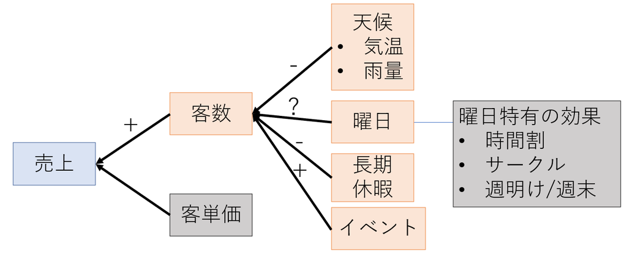

## 仮説（つづき）

1. １日の売上は，客数が１人増加するとどれだけ増加する？
   - +500円前後？
2. 1日の客数は，それぞれの要因によってどれだけ変動する？

## 変数

| 変数名 | 説明 | 変数名 | 説明 |
| --- | --- | --- | --- |
| `date` | 日付 | `sales` | 純売上 |
| `quantity` | 販売点数 | `n_customers` | 客数 |
| `ACS` | 客単価 | `weekday` | 曜日 |
| `temp` | さいたま市平均気温 | `pre` | さいたま市降水量 |
| `holiday` | 長期休暇営業日[ダミー](https://hideyasusato.github.io/slides/program1_2025_lec12.html#/11) | `OC` | オープンキャンパス営業日[ダミー](https://hideyasusato.github.io/slides/program1_2025_lec12.html#/11) |

## 記述統計分析

### 売上の推移を確認

```python
#折れ線グラフ
import matplotlib.pyplot as plt
plt.plot(df["date"],df["sales"])
plt.ylabel("sales")
plt.xticks(rotation=45)
plt.tight_layout()
plt.show()
```

[output not shown]

- 8月22日,23日はOC
- 4月25日はなに…？

### 売上と客数の関係

```python
#散布図
import matplotlib.pyplot as plt
plt.scatter(df["n_customers"], df["sales"])
plt.xlabel("n_customers")
plt.ylabel("sales")
plt.tight_layout()
plt.show()
```

[output not shown]

- 直線的関係から外れる理由は客単価の相違

## 回帰分析の文法

```python
#以下は実行しない
import statsmodels.api as sm
X = sm.add_constant(X) #定数項
model = sm.OLS(y, X).fit()
```

## 回帰分析の文法（つづき）

- `statsmodels`ライブラリ（統計モデルの推定・検定を行い結果を出力）を使用
- その中の良く使う機能を集めた`statsmodels.api`から呼び出すのが標準
- 長いのでエイリアス（別名）は`sm`
- デフォルトで縦軸切片（定数項）が推定されないので説明変数に`add_constant`を適用
- `OLS` はOrdinary Least Squares method（最小二乗法）

## 結果の表の文法

```python
#以下は実行しない
result_table = model.summary2().tables[1].round(3)
print(result_table)
```

## 結果の表の文法（つづき）

- `summary2`メソッドで結果をpandasで取扱い
  - その場の表示用に`summary`メソッドもある
- `tables`属性から結果の表を抽出
  - 0コ目の表：決定係数，サンプルサイズなど
  - 1コ目の表：推定した係数など
- `round(3)`は小数第三位で四捨五入

## 回帰分析：売上 ~ 客数（図）

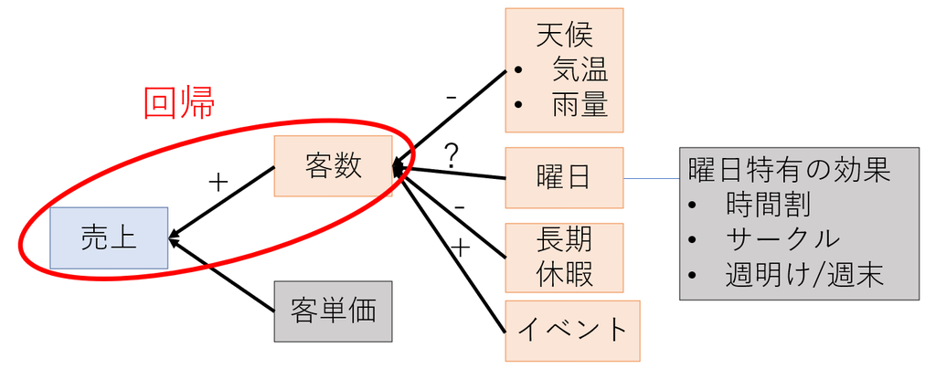

## 回帰分析：売上 ~ 客数（コード）

```python
import statsmodels.api as sm

y = df["sales"]
X = df["n_customers"]

X = sm.add_constant(X) #定数項

model = sm.OLS(y, X).fit()

result_table = (
    model.summary2().tables[1]
    .round(3)
    )
result_table #printしないほうがきれい？
```

## 結果の解釈

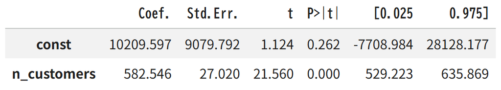

- 客数が1増加すると売り上げは約582円増加
- p値は0.05未満なので5%水準で有意（統計的に約582円は0円と異なる）
- 95%信頼区間は約529円～636円

## 回帰分析：客数 ~ もろもろ

### 図

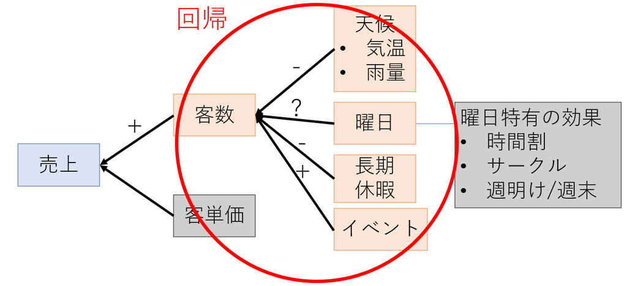

### データ加工

- さきに，各曜日の[ダミー変数](https://hideyasusato.github.io/slides/program1_2025_lec12.html#/11)を作成（リンクはRの授業）
  1. `pd.get_dummies(df["ダミーにしたい変数"])`で一撃
     - bool型なので推定時に数値に変換（`False`は`0`，`True`は`1`に）
  2. ダミー変数の列を作成後，平日5日の列のみ抽出
  3. 元データに5列を[結合](https://hideyasusato.github.io/slides/program2_2025_lec11.html#/%E3%83%87%E3%83%BC%E3%82%BF%E7%B5%90%E5%90%88%E8%A1%8C)

### データ加工（コード）

```python
#1:月～日曜ダミーを作成
weekday_dummies = pd.get_dummies(df['weekday'])
weekday_dummies.head() #チラ見
```

```python
#2:土日を基準とするため平日のみ列抽出
weekday_dummies = weekday_dummies[['Mon', 'Tue', 'Wed', 'Thu', 'Fri']]
weekday_dummies.head() #チラ見
```

```python
#3:元データに結合・上書き
df = pd.concat([df, weekday_dummies],axis=1)
df.head() #チラ見
```

### 推定

```python
import statsmodels.api as sm

y = df["n_customers"]
X = df[["temp", "pre", "holiday","OC","Mon","Tue","Wed","Thu","Fri"]]
X = X.astype(float) #数値化
X = sm.add_constant(X) #定数項

model = sm.OLS(y, X).fit()

result_table = model.summary2().tables[1].round(3)
result_table
```

## 結果

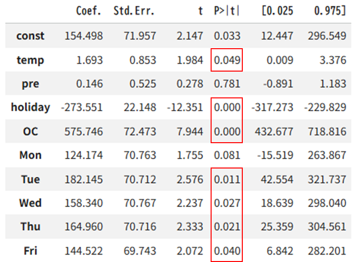

## 結果の解釈

- p値が0.05未満は，`temp`，`holiday`，`OC`，曜日は`Mon`以外
  - `temp`は正・・・春学期が客数多く，秋学期に客数少ない傾向を拾っている
  - `holiday`は負・・・長期休暇営業は大幅に客数減少
  - `OC`は正・・・オーキャンは大盛況
  - 曜日・・・土日営業日を基準としたダミーの効果はどの曜日も正
    - `Mon`は土日営業日と変わらないくらい客数少ない？
    - `Tue`が一番曜日では客数を高める？

## 発展の方向性

- 曜日や気温の売上への影響は春・秋学期で異なる可能性が高いので，サンプルを春・秋に分割
- 天候は最高気温や最低気温なども考慮
- 4月25日に何があったかを明らかにしダミーなどで処理
- そもそも曜日ダミーで処理せず，曜日ごとの時間割やキャンパスの活動などを変数化して代用
- 他のイベント（神業チャレンジ，新商品登場など）も変数化
- 商品側の情報（価格，品数，デザイン），客側の情報（アルバイト給料日，就活時期）なども追加

## 演習

- df_1.csv，df_2.csvはそれぞれ春学期（夏休み含），秋学期（1月14日まで）の分割データ
  - 曜日ダミーはboolで作成済み
- それぞれで被説明変数を客数とした回帰分析を同様に行い結果を比較せよ．

## その他のトピック

### scikit-learn

機械学習による予測・分類・回帰パッケージ

[figure not shown]

### Anaconda

- データ分析に必要なPython一式をまとめて管理できる配布版ディストリビューション
- PCにインストールすれば…
  - Python 本体
  - 主要ライブラリ（numpy, pandas, matplotlib, scikit-learn, statsmodels）
  - Jupyter Notebook / JupyterLab

    を自分で1つずつインストールする必要なし

### VS Code

- 軽くて拡張性の高い，世界的に有名なエディタ
- RStudioの汎用版のイメージ
  - R，Pythonなど様々使用可
- 初期設定やPythonのバージョン管理などで大変なことが多いが，一度環境が整うと便利

### Kaggle

- データ分析・機械学習のための学習・競技プラットフォーム
  - データと課題が公開され，予測精度を競う
    - Titanic：乗客の生死を性別・年齢・同乗家族人数・運賃…などから予測し精度を競う
    - Instacart Market Basket Analysis：オンライン食料品サービスInstacartの購買ログから次回注文でユーザーがどの商品を再購入するか予測
- 実績を積んで就職・転職に有利に

[figure not shown]

- 国内書籍も増加中

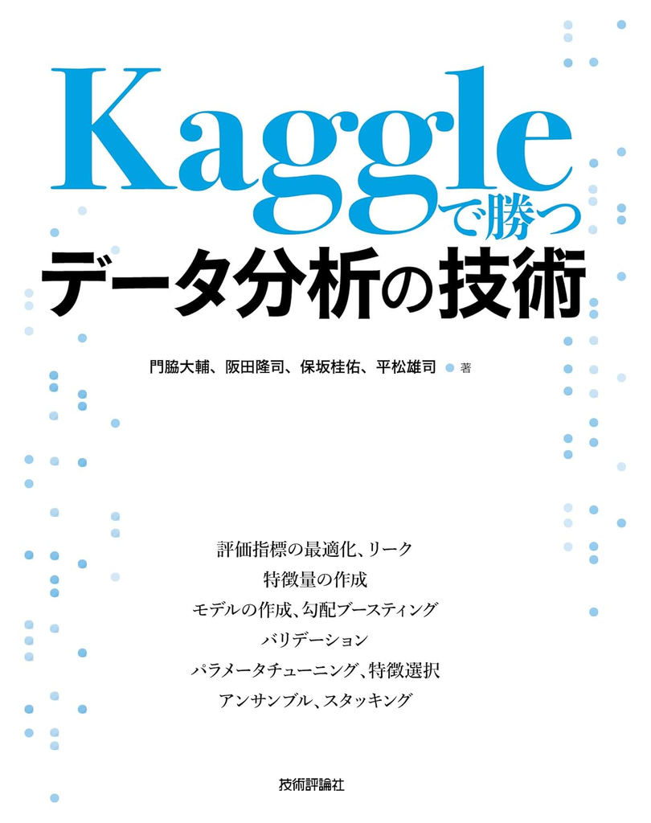

[figure not shown]

[figure not shown]

[figure not shown]

## まとめ

```python
#データはアップロード済みと仮定
import pandas as pd
df = pd.read_csv("df.csv")
df["date"] = pd.to_datetime(df["date"]) #日付型に変換

#折れ線グラフ
import matplotlib.pyplot as plt
plt.plot(df["date"],df["sales"])
plt.ylabel("sales")
plt.xticks(rotation=45)
plt.tight_layout()
plt.show()

#散布図
import matplotlib.pyplot as plt
plt.scatter(df["n_customers"], df["sales"])
plt.xlabel("n_customers")
plt.ylabel("sales")
plt.tight_layout()
plt.show()

#回帰
import statsmodels.api as sm
y = df["sales"]
X = df["n_customers"]
X = sm.add_constant(X) #定数項
model = sm.OLS(y, X).fit()
result_table = model.summary2().tables[1].round(3)
result_table

#曜日ダミー
weekday_dummies = pd.get_dummies(df['weekday'])
weekday_dummies = weekday_dummies[['Mon', 'Tue', 'Wed', 'Thu', 'Fri']]
df = pd.concat([df, weekday_dummies],axis=1)

#回帰
y = df["n_customers"]
X = df[["temp", "pre", "holiday","OC","Mon","Tue","Wed","Thu","Fri"]]
X = X.astype(float) #数値化
X = sm.add_constant(X) #定数項
model = sm.OLS(y, X).fit()
result_table = model.summary2().tables[1].round(3)
result_table
```

## 課題

- ACEの小テスト：「第15回」※本日中に提出！
- ACEのレポート：「第15回」
  - ノートブックを提出（方法は第１回資料参照）